# Churn - Subscription Business Case

# Prologue

This document provides examples of key machine learning tasks while exploring a business case centered around customer churn.

- Example of working locally with large data sets. One of the sources is 30GB. (Valorem has experience with very large Azure data sources too.)
- Several tables were joined to develop a working dataset
- Leverages a machine learning algorithm called `xgboost` - a popular boosted tree algorithm.
- Reproducible research does not have to be boring. The format of this document is an example.
- Emphasizes a common issue in machine learning: know your data intimately and *clearly define the outcome*. In this example, note the emphasis on defining `churn`.

# Use Case Introduction

Valorem worked with Company A, a service provider in the music streaming subscription business. Company A asked Valorem to identify which current subscribers are likely to stop using Company A’s service.

When a subscription is about to expire, the customer can choose to renew or cancel the service. Customers also have the option to auto-renew but can still cancel their membership any time. Most customer subscription lengths are 30 days with most re-subscribing monthly.

`is_cancel` indicates whether a user actively cancels a subscription. *A cancellation does not imply the user has churned*. A user may cancel service due to change of service plans or other reasons. **The criteria of *churn* is no new valid service subscription within 30 days after the current membership expires**.

# Data

A number of data files were provided by Company A. A brief introduction to these tables is introduced below.

```r
# Manage Large File Size - user_logs.csv is 30GB.  #Read takes 15-16 minutes on fatst PC with 16+ GB RAM
PATH <- "../data/subscription/"

user_logs <- fread(paste0(PATH,"user_logs.csv"), sep = ",", select = c('msno', 'num_unq', 'total_secs'),
                   colClasses=c(msno="factor",num_unq="numeric",total_secs="numeric"), stringsAsFactors = T)

numRows_userlogs <- nrow(user_logs)
user_logs <- user_logs[,lapply(.SD, mean, na.rm=TRUE), by = msno]
```

```r
set.seed(12345)

train <- fread(paste0(PATH,"train2.csv"), sep=",", na.strings = "", stringsAsFactors=T)
transactions <- fread(paste0(PATH,"transactions2.csv"), sep=",", na.strings = "", stringsAsFactors=T)
members <- fread(paste0(PATH,"members2.csv"), sep=",", na.strings = "", stringsAsFactors=T)
test <- fread(paste0(PATH,"test0.csv"), sep=",", na.strings = "", stringsAsFactors=T)

#Combine train and test files
test$is_churn <- NA
data <- rbind(train, test)
#data1 <- data[,is_duplicate := as.numeric(duplicated(as.character(data$msno)) | duplicated(as.character(data$msno),fromLast=T))]
data <- mutate(data, is_duplicate = as.numeric(duplicated(msno, fromLast = TRUE)))
#logical indicating if duplication should be considered from the reverse side, i.e., the last (or rightmost) of identical elements would correspond to duplicated = FALSE

members <- members %>% mutate(gender = as.numeric(members$gender))
members <- members %>% mutate(gender = if_else(is.na(gender), 0, gender))
members <- members %>% mutate(reg_fulldate = registration_init_time, registration_init_time = as.Date(as.character(registration_init_time), '%Y%m%d'))
members <- members %>% mutate(reg_year = year(registration_init_time), reg_month = month(registration_init_time), reg_mday = mday(registration_init_time),
                        reg_wday = wday(registration_init_time))
members <- members %>% select(-c(registration_init_time))

#Merge data and members
data <- merge(data, members, by = "msno", all.x = TRUE)

#Reduce size of transactions
transactions <- transactions[transactions$msno %in% levels(data$msno),]

transactions <- transactions %>% group_by(msno) %>% mutate(n_transactions = n())
transactions <- transactions %>% mutate(payment_price_diff = plan_list_price - actual_amount_paid)

#Aggregate by user, get mean of columns.  The transaction dates are useful for now, so remove them
transactions <- transactions %>% group_by(msno) %>% mutate(payment_plan_days = mean(payment_plan_days))
transactions <- transactions %>% group_by(msno) %>% mutate(plan_list_price = mean(plan_list_price), actual_amount_paid = mean(actual_amount_paid),
                                                    payment_price_diff = mean(payment_price_diff))
transactions <- transactions %>% group_by(msno) %>% mutate(is_auto_renew = mean(is_auto_renew), is_cancel = mean(is_cancel), payment_method_id = mean(payment_method_id))

transactions <- distinct(transactions, msno, .keep_all = TRUE)
transactions <- transactions %>% select(-c(transaction_date, membership_expire_date))

#Merge data and transactions
data <- merge(data, transactions, by = "msno", all.x = TRUE)
```

## The Training Data

Train and test sets are split by transaction date.

- The train data include users whose subscription expired in February 2017. (Thus, analyze customer churn or renewal in March 2017.)
- The test data contain users whose subscription expired in March 2017. (Thus, analyze customer churn or renewal in April 2017.)

The train set contains the user ids and whether they have churned. File size = 46MB

- msno: user id
- is_churn: This is the target variable. Churn is defined as whether the user did not continue the subscription within 30 days of expiration. `is_churn = 1` means churn,`is_churn = 0` means renewal.

```r
head(train)
```

```
##                                            msno is_churn
## 1: waLDQMmcOu2jLDaV1ddDkgCrB/jl6sD66Xzs0Vqax1Y=        1
## 2: QA7uiXy8vIbUSPOkCf9RwQ3FsT8jVq2OxDr8zqa7bRQ=        1
## 3: fGwBva6hikQmTJzrbz/2Ezjm5Cth5jZUNvXigKK2AFA=        1
## 4: mT5V8rEpa+8wuqi6x0DoVd3H5icMKkE9Prt49UlmK+4=        1
## 5: XaPhtGLk/5UvvOYHcONTwsnH97P4eGECeq+BARGItRw=        1
## 6: GBy8qSz16X5iYWD+3CMxv/Hm6OPSrXBYtmbnlRtknW0=        1
```

```r
rm(train)
```

## The Test Data

The test set contains the user ids. File size = 45MB

- msno: user id
- is_churn: This is what you will predict. Churn is defined as whether the user did not continue the subscription within 30 days of expiration. `is_churn = 1` means churn,`is_churn = 0` means renewal.

For the test data, `is_churn` is - `NA`. This information will be populated during the machine learning modeling effort below.

```r
head(test)
```

```
##                                            msno is_churn
## 1: ugx0CjOMzazClkFzU2xasmDZaoIqOUAZPsH1q0teWCg=       NA
## 2: f/NmvEzHfhINFEYZTR05prUdr+E+3+oewvweYz9cCQE=       NA
## 3: zLo9f73nGGT1p21ltZC3ChiRnAVvgibMyazbCxvWPcg=       NA
## 4: 8iF/+8HY8lJKFrTc7iR9ZYGCG2Ecrogbc2Vy5YhsfhQ=       NA
## 5: K6fja4+jmoZ5xG6BypqX80Uw/XKpMgrEMdG2edFOxnA=       NA
## 6: ibIHVYBqxGwrSExE63/omeDD99M5vYB3CN2HzkEY+eM=       NA
```

## The Transactional Data

Transactions of users. File size = **1.7GB**

- msno: user id
- payment_method_id: payment method
- payment_plan_days: length of membership plan in days
- plan_list_price: in New Taiwan Dollar (NTD)
- actual_amount_paid: in New Taiwan Dollar (NTD)
- is_auto_renew
- transaction_date: format `%Y%m%d`
- is_cancel: whether or not the user canceled the membership in this transaction.

```r
head(transactions)
```

```
## # A tibble: 6 x 9
## # Groups:   msno [6]
##                                           msno payment_method_id
##                                         <fctr>             <dbl>
## 1 YyO+tlZtAXYXoZhNr3Vg3+dfVQvrBVGO8j1mfqe4ZHc=                41
## 2 AZtu6Wl0gPojrEQYB8Q3vBSmE2wnZ3hi1FbK1rQQ0A4=                41
## 3 yvj6zyBUaqdbUQSrKsrZ+xNDVM62knauSZJzakS9OW4=                39
## 4 KN7I82kjY0Tn76Ny95ncqBUVbO7b8AXrOPqZutKpxIM=                21
## 5 m5ptKif9BjdUghHXXomSezy5ohJiHm85PE13f/3kQaw=                39
## 6 uQxbyACsPOEkTIrv9jZgoGXelGBW81ZsSZKy9fhj5Z8=                39
## # ... with 7 more variables: payment_plan_days <dbl>,
## #   plan_list_price <dbl>, actual_amount_paid <dbl>, is_auto_renew <dbl>,
## #   is_cancel <dbl>, n_transactions <int>, payment_price_diff <dbl>
```

```r
rm(transactions)
```

## The User Logs

Daily user logs describe the listening behaviors of customers. File size = **30GB**

- msno: user id
- date: format `%Y%m%d`
- num_25: # of songs played less than 25% of the song length
- num_50: # of songs played between 25% to 50% of the song length
- num_75: # of songs played between 50% to 75% of of the song length
- num_985: # of songs played between 75% to 98.5% of the song length
- num_100: # of songs played over 98.5% of the song length
- num_unq: # of unique songs played
- total_secs: total seconds played

```r
head(user_logs)
```

```
##                                            msno   num_unq total_secs
## 1: rxIP2f2aN0rYNp+toI0Obt/N/FYQX8hcO1fTmmy2h34=  7.443662   2219.185
## 2: yxiEWwE9VR5utpUecLxVdQ5B7NysUPfrNtGINaM2zA8= 37.960184  12963.493
## 3: PNxIsSLWOJDCm7pNPFzRO/6Mmg2WeZA2nf6hw6t1x3g= 14.870690   4170.763
## 4: KXF9c/T66LZIzFq+xS64icWMhDQE6miCZAtdXRjZHX8= 11.974359   2458.709
## 5: oy2721XIrBu+MEh8XjPTlt5b7gCronoHf/oFN+YwIv8= 39.424303  13858.503
## 6: zD6AnHn/qhjoROJjnwmKUsKJ1Xj4nZ3fJzVShr+LISo= 72.241913  22270.365
```

```r
rm(user_logs)
```

## The Members Data

User information. File size = 361MB

- msno
- city
- bd: age. Note: this column has outlier values ranging from -7000 to 2015, please use your judgement.
- gender
- registered_via: registration method
- registration_init_time: format `%Y%m%d`

```r
head(members)
```

```
##                                           msno city bd gender
## 1 Rb9UwLQTrxzBVwCB6+bCcSQWZ9JiNLC9dXtM1oEsZA8=    1  0      0
## 2 +tJonkh+O1CA796Fm5X60UMOtB6POHAwPjbTRVl/EuU=    1  0      0
## 3 cV358ssn7a0f7jZOwGNWS07wCKVqxyiImJUX6xcIwKw=    1  0      0
## 4 9bzDeJP6sQodK73K5CBlJ6fgIQzPeLnRl0p5B77XP+g=    1  0      0
## 5 WFLY3s7z4EZsieHCt63XrsdtfTEmJ+2PnnKLH5GY4Tk=    6 32      1
## 6 yLkV2gbZ4GLFwqTOXLVHz0VGrMYcgBGgKZ3kj9RiYu8=    4 30      2
##   registered_via reg_fulldate reg_year reg_month reg_mday reg_wday
## 1             11     20110911     2011         9       11        1
## 2              7     20110914     2011         9       14        4
## 3             11     20110915     2011         9       15        5
## 4             11     20110915     2011         9       15        5
## 5              9     20110915     2011         9       15        5
## 6              9     20110916     2011         9       16        6
```

```r
rm(members)
```

## Data - Putting It Altogether

`data` is the combination of test, train, transaction and members that was created in R code. There are 1963891 records.

```r
head(data)
```

```
##                                           msno is_churn is_duplicate city
## 1 +++hVY1rZox/33YtvDgmKA2Frg/2qhkz12B9ylCvh8o=        0            1    1
## 2 +++hVY1rZox/33YtvDgmKA2Frg/2qhkz12B9ylCvh8o=       NA            0    1
## 3 +++l/EXNMLTijfLBa8p2TUVVVp2aFGSuUI/h7mLmthw=       NA            0   15
## 4 +++l/EXNMLTijfLBa8p2TUVVVp2aFGSuUI/h7mLmthw=        0            1   15
## 5 +++snpr7pmobhLKUgSHTv/mpkqgBT0tQJ0zQj6qKrqc=        0            1    1
## 6 +++snpr7pmobhLKUgSHTv/mpkqgBT0tQJ0zQj6qKrqc=       NA            0    1
##   bd gender registered_via reg_fulldate reg_year reg_month reg_mday
## 1  0      0              7     20140608     2014         6        8
## 2  0      0              7     20140608     2014         6        8
## 3 26      2              9     20101118     2010        11       18
## 4 26      2              9     20101118     2010        11       18
## 5  0      0              7     20140927     2014         9       27
## 6  0      0              7     20140927     2014         9       27
##   reg_wday payment_method_id payment_plan_days plan_list_price
```

[output cut: 20 more lines]

# Understanding Churn

To undersntand how Company A defines `churn`, follow the scenarios below.

Imagine a customer engagement sequence consisting of `transaction date`, `membership expiration date`, and `is_cancel`):

| Transaction Date | Membership Expiration Date | Canceled |
| --- | --- | --- |
| 2017-01-01 | 2017-02-28 | False |
| 2017-02-25 | 0217-03-15 | False |
| 2017-04-30 | 3017-05-20 | False |

Consider a more complex example. A customer has the following transaction sequence:

| Transaction Date | Membership Expiration Date | Canceled |
| --- | --- | --- |
| 2017-01-01 | 2017-02-28 | False |
| 2017-02-25 | 0217-04-03 | False |
| 2017-03-15 | 2017-03-16 | True |
| 2017-04-01 | 2017-06-30 | False |

Now consider the a sequence indicating the user does not falls in our scope of prediction:

| Transaction Date | Membership Expiration Date | Canceled |
| --- | --- | --- |
| 2017-01-01 | 2017-02-28 | False |
| 2017-02-25 | 0217-04-03 | False |
| 2017-03-15 | 2017-03-16 | True |
| 2017-03-18 | 2017-04-02 | False |

Note the 3rd entry has member ship expiration date falls in 2017-03-16, but the fourth entry extends the membership expiration date to 2017-04-02, not between 2017-03-01 and 2017-03-31, so we will not make a prediction for the user.

> The way **churn** is defined is critical!

# Model Code

To model and forecast the customers most likely to leave Company A, Valorem implemented a boosted tree algorithm called XGBoost. While other models were initially considered, XGBoost provided the speed and accuracy needed. A detailed explanation on XGBoost is beyond the scope of this business case, but here is a [good resource](https://xgboost.readthedocs.io/en/latest/) to learn about the algorithm (even if you are not a data scientist).

XGBoost output can be challenging to interpret. However, as an example, here is output that Valorem provides as evidence XGBoost is a good solution for this business case:

```r
xgb_cv$evaluation_log
```

```
##       iter train_logloss_mean train_logloss_std test_logloss_mean
##    1:    1          0.6764204      0.0006089902         0.6764290
##    2:    2          0.6597872      0.0007368293         0.6597990
##    3:    3          0.6436672      0.0007150310         0.6436820
##    4:    4          0.6282328      0.0007280306         0.6282546
##    5:    5          0.6136248      0.0008965622         0.6136524
##   ---
##  996:  996          0.0896422      0.0013491714         0.0914026
##  997:  997          0.0896408      0.0013496258         0.0914018
##  998:  998          0.0896384      0.0013486140         0.0914008
##  999:  999          0.0896366      0.0013502500         0.0913996
## 1000: 1000          0.0896354      0.0013510055         0.0913992
##       test_logloss_std
##    1:     0.0006071873
##    2:     0.0007257077
##    3:     0.0006985869
##    4:     0.0007151978
##    5:     0.0008762649
##   ---
##  996:     0.0009108018
##  997:     0.0009112566
##  998:     0.0009110805
##  999:     0.0009123834
## 1000:     0.0009121617
```

Note how the loss values decrease significantly from the first test to the last test.

```r
#Prepare for xgb
cvFolds <- createFolds(data$is_churn[!is.na(data$is_churn)], k=5, list=TRUE, returnTrain=FALSE)
varnames <- setdiff(colnames(data), c("msno", "is_churn"))
#Xgboost manages only numeric vectors.
train_sparse <- Matrix(as.matrix(data[!is.na(data$is_churn), varnames]), sparse=TRUE)
test_sparse <- Matrix(as.matrix(data[is.na(data$is_churn), varnames]), sparse=TRUE)
y_train <- data[!is.na(data$is_churn), 2]
test_ids <- data[is.na(data$is_churn), 1]

dtrainObject <- xgb.DMatrix(data = train_sparse, label = y_train)
dtestObject <- xgb.DMatrix(data = test_sparse)

param <- list(booster = "gbtree", objective = "binary:logistic", eval_metric = "logloss", eta = .02, gamma = 1, max_depth = 6, min_child_weight = 1,
              subsample = .8, colsample_bytree = .8)

xgb_cv <- xgb.cv(data = dtrainObject, params = param, nrounds = 1000, maximize = FALSE, prediction = TRUE, folds = cvFolds, print_every_n = 10, early_stopping_round = 50)

best_iter <- xgb_cv$best_iteration

xgb_model <- xgb.train(data = dtrainObject, params = param, watchlist = list(train = dtrainObject), nrounds = best_iter, verbose = 1, print_every_n = 100)

names <- dimnames(train_sparse)[[2]]
importance_matrix <- xgb.importance(names, model = xgb_model)
```

While the output data from XGBoost may not be easily interpreted, a plot derived from XGBoost is both intuitive and informative. Below, XGBoost provides insight into the variables that influence whether a Customer of Company A is likely to churn.

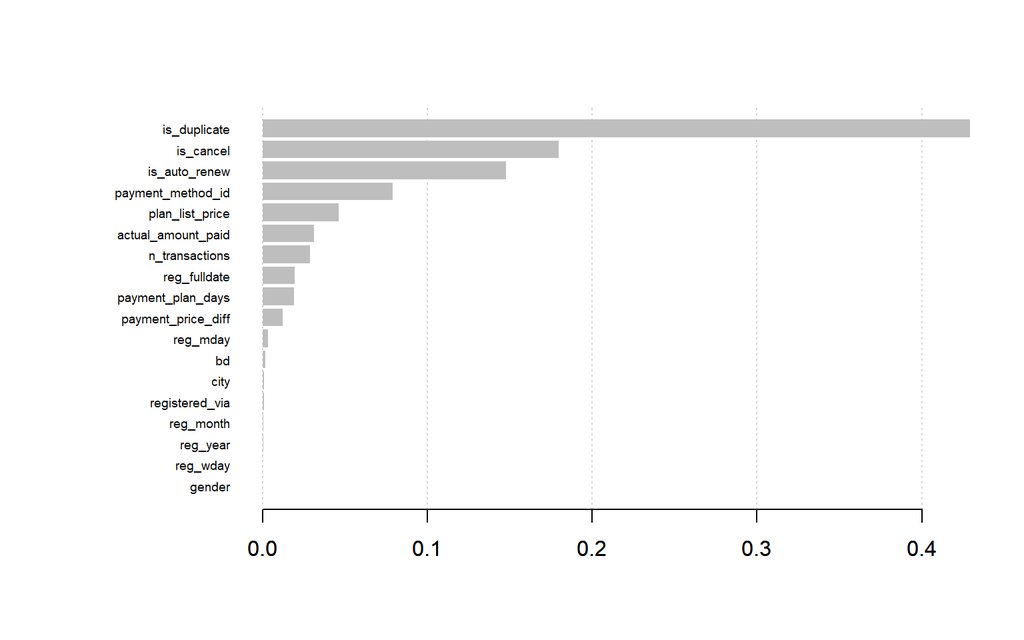

```r
xgb.plot.importance(importance_matrix)
```

Finally, the results from the modeling are actionable. Valorem provided the information below so Company A could identify which specific customers are most likely to churn - the higher the value - the more likely to drop the music service.

Armed with this information, Company A developed direct marketing programs and sales to individuals and to the groups of customers most likely to churn based on the information provided by Valorem’s customer churn machine learning model.

```r
preds <- data.frame(msno = test_ids, is_churn=predict(xgb_model, dtest))
preds <- merge(test[,1], preds, by="msno", all.x=T, sort=F)
```

```r
head(preds, 15)
```

```
##                                            msno  is_churn
## 1  iQP8d2sfHWJWKrFZJJe7AGtUalJcxubHI195lmK9ZBA= 0.9685251
## 2  P5/Sn0Alo730+6SSb2Z6LBDR1kxysH/lFgKUxkXXLzw= 0.9672123
## 3  NCuqANrtrjVkqhN2u2hhgpcHWMnn3o+JlC7Bw0uWM5A= 0.9636856
## 4  pWNhN0UVSnz8LipOlnWuuST6FRKdxvnXlxVmDM0jQFc= 0.9636856
## 5  BbVywdVL4zSQ9C8C1HyE+5bmGDf49agh0lZG3+4U4N0= 0.9636856
## 6  1URL1Obr7TTvT+RXNqodZcBUSlp7MtQOeaDiSzIfaio= 0.9636856
## 7  +JFd4yanl+PON2u6NGjPgxS3eLnMkobq4nt3Pv1HR7I= 0.9636856
## 8  cfHLJbvrcik8bD+fkQ3byM8YWkv+ceZX0fwx4BCoFFY= 0.9636856
## 9  6C0aCev+L9l/0N8yRyWz6tLia3OVoBKDpZwDhJW1Lzc= 0.9636856
## 10 43m8QNMaqrzoCqIUxqnWaf2mYAkaJbAAxnlpqILqHeo= 0.9636856
## 11 UWFdk/xtmJAhENbCODclBAdvxER3duriYhvViULLtv4= 0.9636856
## 12 nMIR5od5ct6kKalln1MkSlyu0YthCfenoZWhPeBlZgM= 0.9636856
## 13 kH/Oa7g8GRfQ2p2/Ay1EZkNtuq+yolmAvk+5DbIHQao= 0.9636856
## 14 ZVfkaXs2AQiFR0BPT5wXinUmWJaJf44aOS/u91/PrBM= 0.9636856
## 15 aOE5ajtGIEQSj6hAEBjSGOGa9I8Og884Ku+qgLar1s0= 0.9636856
```